# US Storm Cost Analysis

Greg Stephenson

25 November 2016

## Synopsis

This is an analysis of the cost of US natural disasters between 1950 and 2011. The data analised is drawn from the NOAA Database, and financial costs (property and crop damage) are scaled for inflation. Quantities of injury are raw numbers, not per 100,000, and thus do not reflect the change in population size or density.

The findings indicate that financially, floods have caused the most damage (~$2 Trillion), however the second most damaging event type is tornados. This is significant as tornados are also the leading cause of weather related fatalities AND injuries by an appreciable margin.

## Data Processing

Two sources of data have been utilised to generate this analysis. The first is the provided “National Weather Service Instruction 10-1605” dataset of events recorded between 1950 and 2011. The second is the CPI Detailed Report Data for October 2016, Table 24. This is used to scale disaster costs to the equivalent 2015 dollar value.

```r
rawData <- read.csv("Data/repdata%2Fdata%2FStormData.csv.bz2")
inflationData <- read.csv("Data/cpid1610 T24.csv")
row.names(inflationData) <- inflationData$Year

# Reduce Table for memory purposes
reducedTable <- rawData[,c("BGN_DATE","EVTYPE","FATALITIES","INJURIES","PROPDMG","PROPDMGEXP","CROPDMG","CROPDMGEXP")]
remove(rawData)
```

Processing the data includes the following steps:

1. Produce consolidated cost values by translating the exponent columns into numeric values and then using these to produce a single number for each event.
2. Reducing the close to 1000 event types to a more manageable number. This is achieved by the use of regular expression matching to alter the type to a single inclusive weather event type. As an example, all hurricanes listed by name are consolidated into one event type, “HURRICANE”. This is due to a number of data entry innacuracies in the dataset, which have the potential to heavily skew the results by subsetting major event types.
3. Creation of two sub tables relevant to health and cost. These reduce the number of rows by filtering from each all events that contain no injuries/fatalities or dollar value cost, repectively. This is done to speed processing and allow for events to be dropped on a more relevant basis than would be the case if these were looked at in combination.
4. All dollar vlues in the Cost table are then summed (crop and property damage) and adjusted for inflation, to prevent the decrease in the value of the dollar affecting the results.

Please see the following processing code for an exact description of the process.

```r
# Produce raw costs from cost*exp
levels(reducedTable$PROPDMGEXP) <- c("0","0","0","0","0","1","2","3","4","5","6","7","8","9","2","2","3","6","6")
reducedTable$propDmgCost <- reducedTable$PROPDMG * (10^(as.numeric(reducedTable$PROPDMGEXP)))
levels(reducedTable$CROPDMGEXP) <- c("0","0","0","2","9","3","3","6","6")
reducedTable$cropDmgCost <- reducedTable$CROPDMG * (10^(as.numeric(reducedTable$CROPDMGEXP)))

# Par down Event Types
newFactors <- as.character(reducedTable$EVTYPE)

filter <- c("hurricane","typh","thund|tstm","torn","fire","bliz","winter","flood","rain","summary","hail","high wind","snow","ice|icy","mud","extreme|unseason|record","lightn","volcan","tropical","wind","coast|surf|swell|wave|marine|sea", "heat")

eventTypes <- c("hurricane","typhoon","thunderstorm","tornado","fire","blizzard","winter","flood","rain","summary","hail","high wind","snow","ice","mud","extreme temperatures", "lightning", "volcanic activity", "tropical storms", "high wind", "ocean related", "heat")

for(i in 1:length(filter)){
  cF <- grep(filter[i], newFactors, ignore.case = TRUE, value = FALSE)
  newFactors[cF] <- eventTypes[i]
}

reducedTable$MajorEventTypes <- newFactors

costTab <- subset(reducedTable, reducedTable$propDmgCost != 0 | reducedTable$cropDmgCost != 0)
healthTab <- subset(reducedTable, reducedTable$FATALITIES != 0 | reducedTable$INJURIES != 0)

# Adjust for inflation
costTab$Year <- as.character(costTab$BGN_DATE)
costTab$Year <- as.POSIXct(costTab$Year, format="%m/%d/%Y %H:%M:%S")
costTab$Year <- as.integer(strftime(costTab$Year, "%Y"))
costTab$totalCost <- costTab$PROPDMG
for(i in seq(1:length(costTab$Year))){
  costTab$totalCost[i] <- (costTab$propDmgCost[i] + costTab$cropDmgCost[i])*inflationData[as.character(costTab$Year[i]), "Normalised"]
}
```

## Results

In order to generate an ordered list of disasters ranked by financial cost and health impacts, we have aggregated the total recorded value of all events. Points to note are that a more in-depth analysis (allowing more than the 3 plot limit) would have included a discussion of the average cost per event, likelyhood of occurance, and health effects scaled per 100k people.

As no quantitative method to determine the relative severity of injury vs death has been provided, I have opted to split the two into seperate plots for later decision making.

Plotting code is only shown to comply with Point 13 of the marking guide.

```r
# Aggregate costs by major event type
ConsolidatedCosts <- aggregate(. ~MajorEventTypes, data=costTab, sum)
ConsolidatedCosts <- ConsolidatedCosts[with(ConsolidatedCosts, order(-totalCost)),]
ConsolidatedCosts$MajorEventTypes <- toupper(as.character(ConsolidatedCosts$MajorEventTypes))

# Aggregate health effects by major event type
ConsolidatedHealth <- aggregate(. ~MajorEventTypes, data=healthTab, sum)
ConsolidatedHealth$MajorEventTypes <- toupper(as.character(ConsolidatedHealth$MajorEventTypes))
ConsolidatedFatalities <- ConsolidatedHealth[with(ConsolidatedHealth, order(-FATALITIES)),]
ConsolidatedInjuries <- ConsolidatedHealth[with(ConsolidatedHealth, order(-INJURIES)),]
```

### Financial Cost

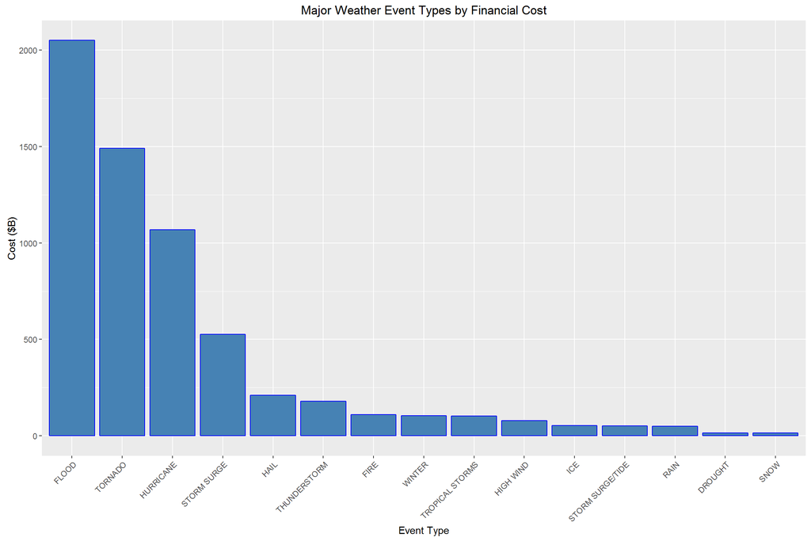

```r
ggplot(ConsolidatedCosts[1:15,], aes(x=reorder(MajorEventTypes, -totalCost), y = (totalCost/1000000000))) + geom_bar(stat="identity", color = "blue", fill = "steelblue") + labs(title="Major Weather Event Types by Financial Cost", x="Event Type", y="Cost ($B)") + theme(axis.text.x = element_text(angle=45, hjust=1))
```

As shown in the chart, the most financially severe event type is FLOOD with a combined value of $2,051 Billion. This is followed by TORNADO, HURRICANE, and STORM SURGE.

### Health Effects

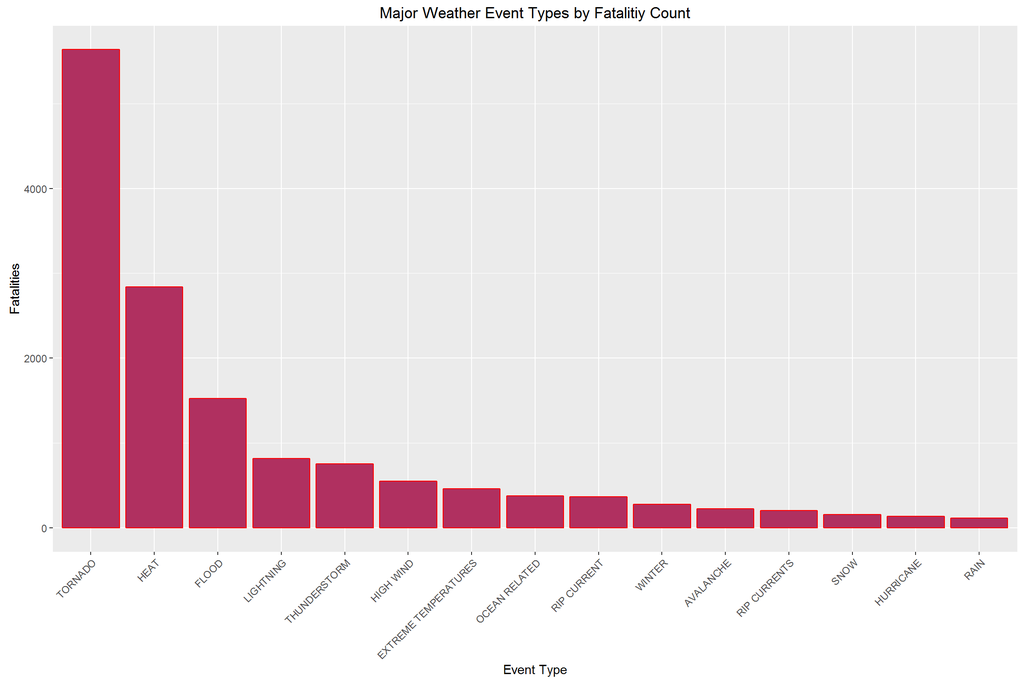

```r
ggplot(ConsolidatedFatalities[1:15,], aes(x=reorder(MajorEventTypes, -FATALITIES), y = FATALITIES)) + geom_bar(stat="identity", color = "red", fill = "maroon") + labs(title="Major Weather Event Types by Fatalitiy Count", x="Event Type", y="Fatalities") + theme(axis.text.x = element_text(angle=45, hjust=1))
```

The leading cause of weather related fatalities in the US is TORNADO related events, followed by HEAT, FLOOD, and LIGHTNING. It is interesting to note that extremes of heat are a leading cause of human loss, although they do not appear to cause significant property or crop damage in this analysis. A deeper investigation into the correlation between events of type ‘heat’ and ‘fire’ would be beneficial to prevention planning priorities.

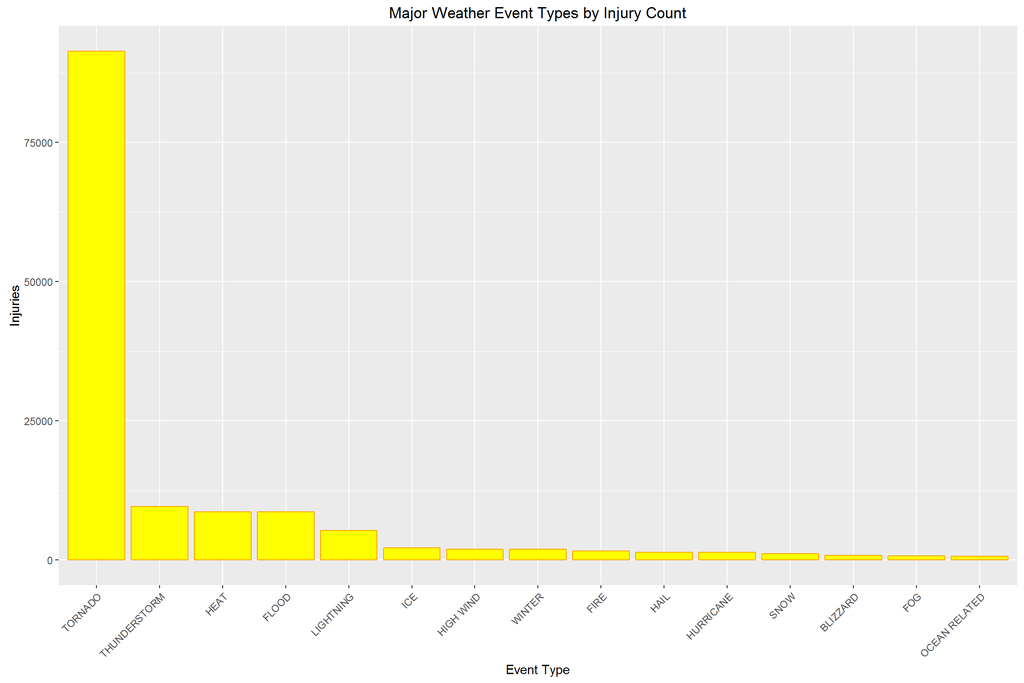

```r
ggplot(ConsolidatedInjuries[1:15,], aes(x=reorder(MajorEventTypes, -INJURIES), y = INJURIES)) + geom_bar(stat="identity", color = "orange", fill = "yellow") + labs(title="Major Weather Event Types by Injury Count", x="Event Type", y="Injuries") + theme(axis.text.x = element_text(angle=45, hjust=1))
```